# LARisk: An R package for Lifetime Attributable Risk Calculation

## Introduction

The R package, `LARisk`, to compute lifetime attributable risk (LAR) of radiation-induced cancer can be helpful with enhancement of the flexibility in research of projected risks of radiation-associated cancers. `LARisk` produces LAR estimates considering various options or arguments. In addition, it is possible to handle large-size data easily and compute LAR values by the group such as occupation, sex, age, group, etc., which can provide research topics for radiation-associated cancer risk.

This document provides a detailed description of the `LARisk` package with some examples. If the package is installed, then we can load it into an R session by

```r
library(LARisk)
```

## Arguments of the `LAR` function

The `LARisk` package has 3 main functions for estimating lifetime attributable risk such as `LAR`, `LAR_batch` and `LAR_group`. `LAR` is a basic function to compute individual LAR values. And the others are extended functions to handle large batch data and calculate LAR estimates by group. The description of each function is in **Functions for estimating LAR**.

```r
LAR(data, basedata, sim=300, seed=99, current=as.numeric(substr(Sys.Date(),1,4)),
    ci=0.9, weight=NULL, DDREF=TRUE, basepy=1e+05)
```

The following table shows the arguments of the `LAR` function.

| Arguments | Description |
| --- | --- |
| data | A data frame containing demographic and exposure information |
| basedata | A list of data of lifetime and incidence rate tables |
| sim | A scalar for the number of iteration |
| seed | A scalar for a random seed number |
| current | A scalar for a current year |
| ci | A scalar for confidence level to compute confidence intervals for LAR estimates |
| weight | A list containing values on [0,1] to compute LAR values based on ERR and EAR models for each cancer site |
| DDREF | Logical. Whether apply the dose and dose-rate effectiveness factor for chronic exposure |
| basepy | A scalar for the number of base person-years |

### data

The **data** should have some prerequisite information such as **sex** and birth year(s) (**birth**), exposure year (**exposure**), exposed dose distributions (**dosedist**), fixed exposed radiation dose or parameters of dose distributions (**dose1**, **dose2**, **dose3**), sites where exposed (**site**), and exposure rate (**exposure_rate**). The name of variables in data should be written as expressed.

The following table expresses the essential variables of the argument, **data**.

| Variables | Format |
| --- | --- |
| sex | one of the character strings ‘*male*’ or ‘*female*’ |
| birth | numeric |
| expposure | numeric |
| site | one of the chracter strings ‘*stomach*’, ‘*colon*’, ‘*liver*’, ‘*lung*’, ‘*breast*’, ‘*ovary*’, ‘*uterus*’, ‘*prostate*’, ‘*bladder*’, ‘*brain/cns*’, ‘*thyroid*’, ‘*remainder*’, ‘*oral*’, ‘*oesophagus… |
| exposure_rate | one of the character strings ‘*chronic*’ or ‘*acute*’ |
| dosedist | one of the character strings ‘*fixedvalue*’, ‘*lognormal*’, ‘*normal*’, ‘*triangular*’, ‘*logtriangular*’, ‘*uniform*’, ‘*loguniform*’ |
| dose1 | numeric |
| dose2 | numeric |
| dose3 | numeric |

Because `LAR` is the function for each object, it is logically trivial that all **sex** and **birth** are same. Also, since the event dates of exposure must occur after the birth date, **exposure** should be larger than **birth**.

```r
ex_data <- data.frame(sex = 'male', birth = 1900, exposure = 1980,
                  site = 'stomach', exposure_rate = "chronic",
                  dosedist = 'fixedvalue', dose1 = 10, dose2=NA, dose3=NA)

LAR(ex_data, basedata=list(life2010, incid2010)) ## error
```

```
#> Error in check_data(data, current): Age is not allowed to be greater than 100 years.
```

The maximum age in the function is set as 100 years old. If the data contains a birth year which makes attained age over 100, it occurs error.

For **site**, we put the irradiated organ site or cancer-site. `LAR` estimates excess cases with the site as ‘*stomach*’, ‘*colon*’, ‘*liver*’, ‘*lung*’, ‘*breast*’, ‘*ovary*’, ‘*uterus*’, ‘*prostate*’, ‘*bladder*’, ‘*brain/cns*’, ‘*thyroid*’, ‘*remainder*’, ‘*oral*’, ‘*oesophagus*’, ‘*rectum*’, ‘*gallbladder*’, ‘*pancreas*’, ‘*kidney*’, ‘*leukemia*’. In particular, **site** that are applicable in `LAR` differ by gender(**sex**). For *male*, ‘*breast*’, ‘*ovary*’ and ‘*uterus*’ are not allowed. Similarly, for *female*, ‘*prostate*’ is not allowed.

In **dosedist**, we insert the distribution of the exposed dose. It can have ‘*fixedvalue*’, ‘*lognormal*’, ‘*normal*’, ‘*triangular*’, ‘*logtriangular*’, ‘*uniform*’ or ‘*loguniform*’. Each distribution demands essential parameters. For instance, if the exposed dose has a normal distribution with the mean of 2.3 and the standard deviation of 0.8, we input `dose1=2.3`, `dose2=0.8` and `dose3=NA`. If the dose has the fixed value of 3.2, we add values as`dose1=3.2`, `dose2=NA` and `dose3=NA`.

| dose distribution | dose1 | dose2 | dose3 |
| --- | --- | --- | --- |
| fixedvalue | value | NA | NA |
| lognormal | median | geometric standard deviation | NA |
| normal | mean | standard deviation | NA |
| triangular | minimum | mode | maximum |
| logtriangular | minimum | mode | maximum |
| uniform | minimum | maximum | NA |
| loguniform | minimum | maximum | NA |

### basedata

The `LAR` and the other extended functions need lifetime and cancer incidence rate tables. We put these tables to the argument ‘**basedata**’ in which the first element is lifetime table and the second element is cancer incidence rate table.

```r
LAR(data,
    basedata = list("the first is lifetime table", "the second is cancer incidence rate table"))
```

`LARisk` includes these tables which were made in 2010 and 2018 in Korea: `life2010`, `incid2010`, `life2018` and `incid2018`. Thus we can estimate the risk for the Korean population in 2010 or 2018 using these tables.

If we want to estimate the risks of the other population, we’ll need the lifetime and cancer incidence rate tables of the population. Similar to **data**, lifetime and cancer incidence rate tables must follow the specified format.

```r
head(life2010)      ## lifetime table of the Korean in 2010.
```

```
#>   Age Prob_d_m Prob_d_f
#> 1   0  0.00369  0.00275
#> 2   1  0.00032  0.00030
#> 3   2  0.00025  0.00022
#> 4   3  0.00018  0.00015
#> 5   4  0.00015  0.00011
#> 6   5  0.00013  0.00009
```

The columns of a lifetime table are consist of ‘*Age*’, ‘*Prob_d_m*’, and ‘*Prob_d_f*’. *Prob_d_m* and *Prob_d_f* are the probabilities of death of male and female, respectively.

```r
head(incid2010)     ## cancer incidence rate table of the Korean in 2010.
```

```
#>   Site Age Rate_m Rate_f
#> 1 oral   0    0.2    0.1
#> 2 oral   1    0.2    0.1
#> 3 oral   2    0.2    0.1
#> 4 oral   3    0.2    0.1
#> 5 oral   4    0.2    0.1
#> 6 oral   5    0.2    0.2
```

Also, the columns of a cancer incidence rate table consist of ‘*Site*’, ‘*Age*’, ‘*Rate_m*’, and ‘*Rate_f*’. *Rate_m* and *Rate_f* are incidence rates of each cancer site of male and female, respectively. The tables should have the range of age from 0 to 100 one by one.

### weight

**weight** is used to estimate LAR through the weighted average of LAR estimates based on ERR and EAR models. It has the form of list whose name of elements is site to decide organ and values of them is for a specific value of the weight. For example, if a weight of stomach cancer is 0.5, run the below code.

```r
LAR(data, basedata, weight=list(stomach = 0.5))
```

`LAR` sets the default weight to 0.7 in most cancers. However, in lung cancer, the weight is 0.3, and cancers of breast and thyroid only have weights of 1 for LAR functions based on EAR or ERR models, respectively (see below table).

| Cancer site | LAR_ERR | LAR_EAR | weight |
| --- | --- | --- | --- |
| Most cancer | 70% | 30% | 0.7 |
| Lung | 30% | 70% | 0.3 |
| Breast | 0% | 100% | 0.0 |
| Thyroid | 100% | 0% | 1.0 |
| Gallbladder | 100% | 0% | 1.0 |
| Brain/CNS | 100% | 0% | 1.0 |

### DDREF

**DDREF** (dose and dose-rate effectiveness factor) is the logical option to select whether or not to consider DDREF in the LAR calculation. DDREF is to modify the effect of exposure, especially, for low-dose exposure. In addition, DDREF is considered differently according to exposure rate. However, if the site is leukemia, DDREF dose not apply even if `DDREF = TRUE`.

```r
ex_data <- data.frame(sex = 'male', birth = 1990, exposure = 2015,
                  site = 'leukemia', exposure_rate = "chronic",
                  dosedist = 'fixedvalue', dose1 = 10, dose2=NA, dose3=NA)

LAR(ex_data, basedata=list(life2010, incid2010), DDREF=TRUE)
```

```
#> LAR:
#>   Lower    Mean   Upper
#>  2.6587  5.9803 13.4514
#>
#> Future LAR:
#>          Lower     Mean    Upper
#> F.LAR   2.5882   5.8191  13.0830
#> BFR   538.7711 538.7711 538.7711
#> TFR   541.3593 544.5902 551.8542
#> ---
```

```r
LAR(ex_data, basedata=list(life2010, incid2010), DDREF=FALSE) ## the result are same
```

```
#> LAR:
#>   Lower    Mean   Upper
#>  2.6587  5.9803 13.4514
#>
#> Future LAR:
#>          Lower     Mean    Upper
#> F.LAR   2.5882   5.8191  13.0830
#> BFR   538.7711 538.7711 538.7711
#> TFR   541.3593 544.5902 551.8542
#> ---
```

### other arguments

**seed** is the random seed number. As long as the same seed number is provided, we obtain the same result in anytime. **sim** is the number of simulation runs. Note that as **sim** goes larger, the computation time takes longer although the simulation variation is getting smaller. i.e., even though **seed** is different, the large **sim** yields a similar outcome. In `LARisk`, `sim=300` is default. **basepy** is the baseline person year such as 10,000 person year or 100,000 person year.

```r
LAR(data, basedata, seed=1111)    ## changing seed number, the result is also changed
LAR(data, basedata, sim=1000)     ## the large 'sim' offers a stable simulation result
LAR(data, basedata, basepy=1e+03) ## setting the baseline person-year is 1000
```

**current** is the year to set as the moment of estimation. The default value is set as the system time of the computer. Since it is considered as the current year, we can change the option if we want to set the current time into other years. It recommends that the value should be in form of a year in 4 digits.

```r
LAR(data, basedata, current=2019) ## setting the current year is 2019
```

Changing the current time affects the estimation of future lifetime attributable risk and future baseline risk.

**ci** is the level of significance to provide the confidence interval of LAR estimates, expressed in number between 0 and 1. The default value is 0.9, in other words, the `LAR` function provides the confidence interval at 90% level of significance in default setting.

```r
LAR(data, basedata, ci=0.8) ## setting the confidence level is 0.8
```

## Functions for estimating LAR

As mentioned above, the package `LARisk` includes 3 main functions `LAR`, `LAR_batch`, and `LAR_group` that estimate the LAR values for various cases. These functions can be used for a variety of purposes by users. The functions give the three kinds of estimates such as lifetime risk, future risk and lifetime baseline risk. `LAR` and `F_LAR` are represented as LAR and future LAR estimates with confidence limits (lower and upper) for each cancer site, solid cancer and total.

We will use the toy example data ‘nuclear’ in this section, which is simulated with the assumption that all people are exposed to radiation at the same time (Details on this data are in “**APPENDIX: Datasets in** `LARisk`”).

### `LAR`: the function of estimating LAR for one person

`LAR` is the function to estimate LAR for one person. It returns an object of class `LAR`. `LAR` class contains the risks of the person, information of the person (gender and birth-year), and some options for calculating risks. The following is the table of components in the `LAR` object.

| Values | Description |
| --- | --- |
| LAR | Lifetime attributable risk (LAR) from the time of exposure to the end of the expected lifetime |
| F_LAR | Future attributable risk from current to the expected lifetime |
| LBR | Lifetime baseline risk |
| BFR | Baseline future risk |
| LFR | Lifetime fractional risk |
| TFR | Total future risk |
| current | Current year |
| ci | Confidence level |
| pinfo | Information of the person |

```r
nuclear1 <- nuclear[nuclear$ID=="ID01",]

print(nuclear1)
```

```
#>     ID    sex birth exposure       site exposure_rate   dosedist    dose1 dose2
#> 1 ID01 female  1973     2011      ovary         acute fixedvalue 50.06989    NA
#> 2 ID01 female  1973     2011 oesophagus         acute fixedvalue 50.37462    NA
#> 3 ID01 female  1973     2011    bladder         acute fixedvalue 52.46040    NA
#> 4 ID01 female  1973     2011       lung         acute fixedvalue 55.69177    NA
#> 5 ID01 female  1973     2011  remainder         acute fixedvalue 51.64678    NA
#> 6 ID01 female  1973     2011     rectum         acute fixedvalue 49.37011    NA
#> 7 ID01 female  1973     2011    thyroid         acute fixedvalue 54.14875    NA
#>   dose3 distance
#> 1    NA        1
#> 2    NA        1
#> 3    NA        1
#> 4    NA        1
#> 5    NA        1
#> 6    NA        1
#> 7    NA        1
```

```r
LAR(nuclear1, basedata = list(life2010, incid2010))
```

```
#> LAR:
#>     Lower      Mean     Upper
#>  359.9479  671.3751 1203.8111
#>
#> Future LAR:
#>            Lower       Mean     Upper
#> F.LAR   337.3697   597.7655  1032.216
#> BFR   15992.9219 15992.9219 15992.922
#> TFR   16330.2917 16590.6874 17025.137
#> ---
```

The `LAR` object prints the total LAR , total future LAR, total baseline future risk, and total future risk. If you want the more detailed results, you can use the `summary` function.

```r
summary(LAR(nuclear1, basedata = list(life2010, incid2010)))
```

```
#> Information:
#>     sex birth
#>  female  1973
#>
#> LAR:
#>               Lower     Mean     Upper        LBR    LFR
#> lung        74.5065 156.5247  241.1717  3630.3464 0.0431
#> ovary        4.4880  13.3756   27.6491   697.6095 0.0192
#> bladder     13.0799  30.4405   58.7444   452.0590 0.0673
#> thyroid     83.9986 368.7603  877.5446  7318.8901 0.0504
#> remainder   33.5177  89.1794  169.3327  4237.3935 0.0210
#> oesophagus   0.2000   4.0450   10.4666   116.7920 0.0346
#> rectum       0.2670   9.0496   21.7567  2157.6294 0.0042
#> leukemia     0.0000   0.0000    0.0000     0.0000    NaN
#> solid      359.9479 671.3751 1203.8111 18610.7199 0.0361
#> total      359.9479 671.3751 1203.8111 18610.7199 0.0361
#>
#> Future LAR:
#>               Lower     Mean     Upper        BFR        TFR
#> lung        73.4884 154.5469  238.6027  3574.2001  3728.7470
#> ovary        4.0861  12.0693   25.2806   597.5191   609.5885
#> bladder     13.0173  30.3006   58.5236   452.9404   483.2410
#> thyroid     68.7104 303.3691  745.8708  5117.1159  5420.4850
#> remainder   32.3341  84.9052  160.5547  4066.5835  4151.4887
#> oesophagus   0.1978   3.9420   10.2253   115.9270   119.8690
#> rectum       0.2558   8.6324   20.6083  2068.6359  2077.2682
#> leukemia     0.0000   0.0000    0.0000     0.0000     0.0000
#> solid      337.3697 597.7655 1032.2155 15992.9219 16590.6874
#> total      337.3697 597.7655 1032.2155 15992.9219 16590.6874
#>
#> Confidence Level: 0.9
#> Current Year: 2022
#> ---
```

The `suumary` function provides the person’s gender and year of birth, risks by cancer type, confidence levels, and current year. In `summary` results, the LAR tab includes site-specific LAR, lifetime baseline risk (LBR), and lifetime fractional risk (LFR). Also, the Future LAR tab contains site-specific future LAR, baseline future risk (BFR), and total future risk (TFR).

### `LAR_batch`: the function of estimating LAR for several people

If you want to consider more than one person, you can use `LAR'. But, for large observations, the`LAR_batch`function is useful. Unlike`LAR`, it calculates each persons’ risks after reading multiple people’s data at once.

Since data contains more than one person, the function requires an argument to distinguish each person. `pid` is the argument, which is a vector to distinguish each person in the dataset. For example, suppose that we want to calculate LAR estimates of several people in the `nuclear` dataset. Since the variable “ID” is the person ID for this data, we can estimate the LAR values as follows.

```r
ex_batch <- LAR_batch(nuclear, pid=nuclear$ID, basedata = list(life2010, incid2010))

class(ex_batch)
```

```
#> [1] "LAR_batch" "LAR"
```

```r
class(ex_batch[[1]])
```

```
#> [1] "LAR"
```

The `LAR_batch` returns the `LAR_batch` class object. It is the form of the list of `LAR` class objects which names of elements are IDs for people, i.e., each element of `LAR_batch` class is `LAR` class object. Thus, printing the results of `LAR_batch` is similar to `LAR`.

```r
print(ex_batch, max.id=3)
```

```
#> LAR result of ID01
#>
#> LAR:
#>     Lower      Mean     Upper
#>  359.9479  671.3751 1203.8111
#>
#> Future LAR:
#>            Lower       Mean     Upper
#> F.LAR   337.3697   597.7655  1032.216
#> BFR   15992.9219 15992.9219 15992.922
#> TFR   16330.2917 16590.6874 17025.137
#> ---
#>
#> LAR result of ID02
#>
#> LAR:
#>    Lower     Mean    Upper
#> 308.6326 532.0084 758.9928
#>
#> Future LAR:
#>           Lower       Mean      Upper
#> F.LAR   299.063   518.3091   732.8379
#> BFR   24653.092 24653.0924 24653.0924
#> TFR   24952.155 25171.4015 25385.9303
#> ---
#>
#> LAR result of ID03
#>
#> LAR:
#>     Lower      Mean     Upper
#>  791.5664 1241.2319 1734.6870
#>
#> Future LAR:
#>            Lower      Mean     Upper
#> F.LAR   772.5637  1217.909  1698.646
#> BFR   20338.3442 20338.344 20338.344
#> TFR   21110.9079 21556.253 22036.991
#> ---
#>
#> The results for 17 people are omitted.
```

If you want the minimum results, we can use the `print`. It also runs by default when simply calling the `LAR_batch` class object. Using the `max.id` option, you can control the maximum number of printing results (default is 50).

Similarly, using the `summary`, you can get more detailed results. The result of the function is the same as listing the summary of each person.

```r
summary(ex_batch, max.id=3)
```

```
#> summaries of LAR result :  ID01
#>
#> Information:
#>     sex birth
#>  female  1973
#>
#> LAR:
#>               Lower     Mean     Upper        LBR    LFR
#> lung        74.5065 156.5247  241.1717  3630.3464 0.0431
#> ovary        4.4880  13.3756   27.6491   697.6095 0.0192
#> bladder     13.0799  30.4405   58.7444   452.0590 0.0673
#> thyroid     83.9986 368.7603  877.5446  7318.8901 0.0504
#> remainder   33.5177  89.1794  169.3327  4237.3935 0.0210
#> oesophagus   0.2000   4.0450   10.4666   116.7920 0.0346
#> rectum       0.2670   9.0496   21.7567  2157.6294 0.0042
#> leukemia     0.0000   0.0000    0.0000     0.0000    NaN
#> solid      359.9479 671.3751 1203.8111 18610.7199 0.0361
#> total      359.9479 671.3751 1203.8111 18610.7199 0.0361
#>
#> Future LAR:
#>               Lower     Mean     Upper        BFR        TFR
#> lung        73.4884 154.5469  238.6027  3574.2001  3728.7470
#> ovary        4.0861  12.0693   25.2806   597.5191   609.5885
#> bladder     13.0173  30.3006   58.5236   452.9404   483.2410
#> thyroid     68.7104 303.3691  745.8708  5117.1159  5420.4850
#> remainder   32.3341  84.9052  160.5547  4066.5835  4151.4887
#> oesophagus   0.1978   3.9420   10.2253   115.9270   119.8690
#> rectum       0.2558   8.6324   20.6083  2068.6359  2077.2682
#> leukemia     0.0000   0.0000    0.0000     0.0000     0.0000
#> solid      337.3697 597.7655 1032.2155 15992.9219 16590.6874
#> total      337.3697 597.7655 1032.2155 15992.9219 16590.6874
#>
#> Confidence Level: 0.9
#> Current Year: 2022
#> ---
#>
#> summaries of LAR result :  ID02
#>
#> Information:
#>   sex birth
```

[output cut: 46 more lines]

```
#>
#> Future LAR:
#>               Lower      Mean     Upper       BFR       TFR
#> stomach    279.9070  481.0488  714.4396 10100.598 10581.647
#> prostate  -210.9228   60.7878  308.2314  5286.830  5347.618
#> remainder  394.4592  676.0721 1062.5141  4950.916  5626.988
#> leukemia     0.0000    0.0000    0.0000     0.000     0.000
#> solid      772.5637 1217.9087 1698.6464 20338.344 21556.253
#> total      772.5637 1217.9087 1698.6464 20338.344 21556.253
#>
#> Confidence Level: 0.9
#> Current Year: 2022
#> ---
#>
#> The results for 17 people are omitted.
```

This function requires not only the value distinguishing the person but also the value for the group. `group` is the vector or list that groups the data. The function returns the `LAR_group` class object which is the form of a list of `LAR` class objects.

Suppose that we want to estimate the average LAR of the people in the `nuclear` dataset by the *distance*. Then we can put `group=nuclear$distnace` in `LAR_group`.

```r
ex_group1 <- LAR_group(nuclear, pid = nuclear$ID, group = nuclear$distance,
                       basedata = list(life2010, incid2010))
summary(ex_group1)
```

```
#> summaries of LAR result : Group 1
#>
#> Group Information:
#>     sex count    birth
#>  female    35 1962.600
#>    male    45 1962.222
#>
#> LAR:
#>                Lower     Mean    Upper        LBR     LFR
#> stomach      50.9850  66.2373  87.8936  2926.1714  0.0226
#> colon        43.4301  56.1274  72.3353  2160.0832  0.0260
#> liver         7.0657  10.4933  15.2987   808.9772  0.0130
#> lung         39.1538  53.4791  70.6998  3097.9930  0.0173
#> breast        2.8636   4.2821   6.0646   331.2576  0.0129
#> ovary         0.3206   0.9554   1.9749    49.8292  0.0192
#> uterus        0.0216   0.1491   0.3288    68.4665  0.0022
#> prostate    -15.4917   6.2743  27.6037   960.8121  0.0065
#> bladder      10.5122  16.1598  23.8353   430.7553  0.0375
#> brain/cns     0.7414   1.3918   2.2998    46.3592  0.0300
#> thyroid      67.7618 185.2396 350.2187  1648.0018  0.1124
#> remainder    34.5468  56.8793  88.6948   912.3992  0.0623
#> oral          0.3038   1.3365   2.7663   105.2675  0.0127
#> oesophagus    2.7255   5.3313   8.1798   208.5186  0.0256
#> rectum        0.3667   1.3777   2.5946   618.5623  0.0022
#> gallbladder  -6.2708  -0.9336   4.2742   420.9955 -0.0022
#> pancreas      3.4377   7.4064  11.9408   493.6795  0.0150
#> kidney        1.0530   3.2226   6.5984   203.1165  0.0159
#> leukemia      0.0713   0.2012   0.5677    19.9927  0.0101
#> solid       339.2210 475.4092 659.3305 15491.2456  0.0307
#> total       339.4012 475.6104 659.5318 15511.2384  0.0307
#>
#> Future LAR:
#>                Lower     Mean    Upper        BFR        TFR
#> stomach      48.2294  63.3542  84.7154  2490.0371  2553.3913
#> colon        40.9639  53.4541  69.9636  1902.1381  1955.5921
#> liver         6.0418   9.0587  13.2437   571.8794   580.9381
#> lung         38.4091  52.5642  69.9525  2877.2243  2929.7885
#> breast        2.3678   3.5644   5.0447   157.2215   160.7859
#> ovary         0.2919   0.8621   1.8058    42.6799    43.5420
#> uterus        0.0203   0.1258   0.2655    41.5060    41.6318
```

[output cut: 81 more lines]

```
#> solid    1372.524 2084.9721 2843.2003 4034.3339 0.5168
#> total    1372.524 2084.9721 2843.2003 4034.3339 0.5168
#>
#> Future LAR:
#>              Lower      Mean     Upper       BFR       TFR
#> colon    1209.3299 1768.8959 2468.3009 2227.0219 3995.9179
#> oral        4.7252   12.1299   20.4353   31.9436   44.0735
#> rectum     13.6274  298.2743  595.1193 1753.3920 2051.6663
#> leukemia    0.0000    0.0000    0.0000    0.0000    0.0000
#> solid    1369.2378 2079.3001 2838.2846 4012.3575 6091.6576
#> total    1369.2378 2079.3001 2838.2846 4012.3575 6091.6576
#>
#> Confidence Level: 0.9
#> Current Year: 2022
#> ---
```

The result of the `LAR_group` is similar to those of `LAR_batch`. The difference is the **Group Information tab**, which provides the gender frequency table within the group and the average birth-year within the group, instead of each individuals’ gender and birth-year. The risks are the estimates of the average LAR in groups.

## Write the result in a file

`LARisk` includes the functions which write a result of `LAR`, `LAR_batch`, and `LAR_group`. `write_LAR` is the function that saves the `LAR` class family into a CSV file.

```r
write_LAR(x, filename)
```

In this function, `x` is an object that wants to save into a CSV file. When you put the file name or connection to write into `filename`, the object is saved there. Note that if there exists the csv file which has the same title with `filename`, it would be overlapped. Therefore, before deciding a `file name`, be cautious to check whether or not the name is duplicated. In the same way as above, the result from the LAR batch function can be saved as a CSV file.

If the object is a `LAR` class object, the format of the saved file is that:

|  | Lower | Mean | Upper | F.Lower | F.Mean | F.Upper | LBR | BFR | LFR | TFR |
| --- | --- | --- | --- | --- | --- | --- | --- | --- | --- | --- |
| site-name |  |  |  |  |  |  |  |  |  |  |
| solid |  |  |  |  |  |  |  |  |  |  |
| total |  |  |  |  |  |  |  |  |  |  |

The function exports a table whose row is represented as site-names, solid, total, and whose column is the risks.

Since the `LAR_batch` class object is a list of `LAR` objects, it is difficult to export files in the same form as above. Thus, if the object’s class is `LAR_batch`, the function saves a file whose values are represented in a horizontal way for each organ, solid, and total.

If the class of the object is `LAR_group`, the format of the saved file is the same. In this case, the first column is **GROUP** instead of **PID**.

## Examples

Now, consider the toy example of `organ` data. This data has 20 people which are exposed to radiation several times.

```r
head(organ)
```

```
#>     ID  sex birth exposure       site exposure_rate   dosedist       dose1
#> 1 ID01 male  1985     2011 oesophagus       chronic fixedvalue 0.001954895
#> 2 ID01 male  1985     2011     kidney       chronic fixedvalue 0.003855487
#> 3 ID01 male  1985     2011     rectum       chronic fixedvalue 0.003855487
#> 4 ID01 male  1985     2011    thyroid       chronic fixedvalue 0.005104447
#> 5 ID01 male  1985     2013 oesophagus       chronic fixedvalue 0.089358392
#> 6 ID01 male  1985     2013     kidney       chronic fixedvalue 0.176234606
#>   dose2 dose3 occup
#> 1    NA    NA     1
#> 2    NA    NA     1
#> 3    NA    NA     1
#> 4    NA    NA     1
#> 5    NA    NA     1
#> 6    NA    NA     1
```

Assume that we want to calculate the risks with the current year is 2021. In this example, we calculate the risks for the population in Korea, in 2018.

First, the estimated risks of ‘ID01’ is that:

```r
organ1 <- organ[organ$ID=='ID01',]
ex_organ1 <- LAR(organ1, baseda=list(life2018, incid2018), current=2021)

ex_organ1
```

```
#> LAR:
#>  Lower   Mean  Upper
#> 1.1149 1.6981 2.5132
#>
#> Future LAR:
#>           Lower      Mean     Upper
#> F.LAR    1.1132    1.6759    2.4744
#> BFR   6694.6423 6694.6423 6694.6423
#> TFR   6695.7555 6696.3182 6697.1167
#> ---
```

The estimated LAR of the person ID01 is **1.6981** with the 90% confidence interval **(1.1149, 2.5132)**. The future risk is **1.6759** with the 90% confidence interval **(1.1132, 2.4744)**

```r
summary(ex_organ1)
```

```
#> Information:
#>   sex birth
#>  male  1985
#>
#> LAR:
#>             Lower   Mean  Upper      LBR   LFR
#> thyroid    0.4673 0.9709 1.8205 1771.543 5e-04
#> oesophagus 0.1025 0.1824 0.2729 1048.947 2e-04
#> rectum     0.0978 0.2385 0.4111 2893.126 1e-04
#> kidney     0.1416 0.3064 0.5160 1338.149 2e-04
#> leukemia   0.0000 0.0000 0.0000    0.000   NaN
#> solid      1.1149 1.6981 2.5132 7051.764 2e-04
#> total      1.1149 1.6981 2.5132 7051.764 2e-04
#>
#> Future LAR:
#>             Lower   Mean  Upper      BFR      TFR
#> thyroid    0.4507 0.9512 1.7587 1453.492 1454.443
#> oesophagus 0.1025 0.1823 0.2728 1055.583 1055.766
#> rectum     0.0977 0.2379 0.4108 2877.117 2877.355
#> kidney     0.1406 0.3045 0.5153 1308.450 1308.755
#> leukemia   0.0000 0.0000 0.0000    0.000    0.000
#> solid      1.1132 1.6759 2.4744 6694.642 6696.318
#> total      1.1132 1.6759 2.4744 6694.642 6696.318
#>
#> Confidence Level: 0.9
#> Current Year: 2021
#> ---
```

With `summary`, we can get a more detailed report of the result. By the result, the person *ID01* is a man born in 1985. This person was exposed radiation to thyroid, oesophagus, ‘rectum’, and kidney. Since `leukemia` is not included in this data, the result for `leukemia` is zero.

Consider the risks of the female / male groups of the `organ`.

```r
ex_organ2 <- LAR_group(organ, pid=organ$ID, group=organ$sex,
                       basedata=list(life2018, incid2018), current=2021)

summary(ex_organ2)
```

```
#> summaries of LAR result : Group female
#>
#> Group Information:
#>     sex count    birth
#>  female   166 1976.313
#>
#> LAR:
#>               Lower    Mean   Upper       LBR     LFR
#> colon        0.6832  1.1392  1.7064 1080.1190  0.0011
#> lung         2.3739  2.8990  3.5941 1353.2750  0.0021
#> uterus       0.1447  0.2874  0.4696  338.1363  0.0008
#> bladder      0.9560  1.3026  1.7539  155.9481  0.0084
#> remainder    2.9905  4.5565  6.7692 1875.6871  0.0024
#> oral         0.1509  0.2311  0.3413  130.7238  0.0018
#> oesophagus   0.0203  0.0768  0.1583   18.0691  0.0043
#> rectum       0.2375  0.4315  0.6480  873.1753  0.0005
#> gallbladder -0.1736 -0.0274  0.1067  290.7825 -0.0001
#> pancreas     0.0661  0.1089  0.1608  283.0072  0.0004
#> leukemia     0.0792  0.1800  0.4092   81.1517  0.0022
#> solid        9.3445 11.0056 13.3345 6398.9234  0.0017
#> total        9.5265 11.1856 13.5145 6480.0751  0.0017
#>
#> Future LAR:
#>               Lower    Mean   Upper       BFR       TFR
#> colon        0.6658  1.0964  1.6314 1051.6541 1052.7505
#> lung         2.3673  2.8906  3.5837 1352.5231 1355.4137
#> uterus       0.1423  0.2825  0.4686  296.3270  296.6095
#> bladder      0.9503  1.2916  1.7359  154.4180  155.7096
#> remainder    2.8942  4.4153  6.5409 1792.3971 1796.8124
#> oral         0.1444  0.2181  0.3177  119.1196  119.3377
#> oesophagus   0.0201  0.0762  0.1568   18.0923   18.1685
#> rectum       0.2346  0.4186  0.6327  835.6204  836.0390
#> gallbladder -0.1735 -0.0274  0.1066  292.4045  292.3771
#> pancreas     0.0653  0.1079  0.1591  281.1836  281.2915
#> leukemia     0.0944  0.1773  0.3603   77.5662   77.7435
#> solid        9.1382 10.7697 12.9982 6193.7399 6204.5095
#> total        9.3172 10.9470 13.1770 6271.3060 6282.2530
#>
#> Confidence Level: 0.9
#> Current Year: 2021
```

[output cut: 38 more lines]

```
#> thyroid      0.6714  0.9920  1.3906   331.6146   332.6066
#> remainder    6.5417  7.7960  9.4301  1277.7412  1285.5372
#> oral         0.3365  0.4629  0.6085   326.9197   327.3826
#> oesophagus   0.3778  0.4561  0.5447   296.6060   297.0622
#> rectum       0.2574  0.4175  0.6129   582.9204   583.3379
#> gallbladder -0.2587 -0.0614  0.1289   285.0148   284.9534
#> pancreas     0.4322  0.5781  0.7887   256.1738   256.7519
#> kidney       0.4992  0.6462  0.7967   409.5781   410.2243
#> leukemia     0.3114  0.7470  1.7946    83.8317    84.5786
#> solid       20.8728 23.0132 25.3536 11237.7516 11260.7648
#> total       21.6190 23.7602 26.1058 11321.5832 11345.3434
#>
#> Confidence Level: 0.9
#> Current Year: 2021
#> ---
```

We can also set the variables for group. For example, we want the average risks of female and `occup` is 1

```r
ex_organ3 <- LAR_group(organ, pid=organ$ID, group=list(organ$sex, organ$occup),
                       basedata=list(life2018, incid2018), current=2021)

print(ex_organ3, max.id=3)
```

```
#> LAR result of female.1
#>
#> LAR:
#>  Lower   Mean  Upper
#> 4.7547 6.2051 8.0758
#>
#> Future LAR:
#>           Lower      Mean     Upper
#> F.LAR    4.7348    6.1773    8.0388
#> BFR   3746.8142 3746.8142 3746.8142
#> TFR   3751.5490 3752.9915 3754.8530
#> ---
#>
#> LAR result of male.1
#>
#> LAR:
#>   Lower    Mean   Upper
#> 37.9314 41.3941 45.0670
#>
#> Future LAR:
#>            Lower       Mean      Upper
#> F.LAR    32.3847    35.4936    38.7843
#> BFR   12300.1490 12300.1490 12300.1490
#> TFR   12332.5337 12335.6426 12338.9333
#> ---
#>
#> LAR result of female.4
#>
#> LAR:
#>  Lower   Mean  Upper
#> 0.1310 0.4694 0.8903
#>
#> Future LAR:
#>          Lower     Mean    Upper
#> F.LAR   0.1299   0.4655   0.8830
#> BFR   108.5540 108.5540 108.5540
#> TFR   108.6839 109.0195 109.4369
#> ---
#>
#> The results for 4 groups are omitted.
```

## APPENDIX: Datasets in `LARisk`

The `LARisk` package include two toy example datasets, `nuclear` and `organ`. These datasets are simulated assuming two situation: One is that all people were exposed to radiation at the same time, and the other is that each person was exposed to radiation over a long period of time. Each data has 11 variables, including 9 essential variables for calculating the LAR.

### `nuclear`: a simulated dataset assuming radioactive explosion

`nuclear` was simulated assuming the scenario in which everyone is exposed to radiation at the same time. This data includes 20 people, who were exposed to radiation at the same time in 2011. The age exposed to radiation is from 3 to 81 years old, and there are 10 males and 10 females. All values of `exposure_rate` are `acute` and all values of `dosedist` are `fixedvalue`.

```r
str(nuclear)
```

```
#> 'data.frame':    100 obs. of  11 variables:
#>  $ ID           : chr  "ID01" "ID01" "ID01" "ID01" ...
#>  $ sex          : chr  "female" "female" "female" "female" ...
#>  $ birth        : int  1973 1973 1973 1973 1973 1973 1973 1981 1981 1981 ...
#>  $ exposure     : num  2011 2011 2011 2011 2011 ...
#>  $ site         : chr  "ovary" "oesophagus" "bladder" "lung" ...
#>  $ exposure_rate: chr  "acute" "acute" "acute" "acute" ...
#>  $ dosedist     : chr  "fixedvalue" "fixedvalue" "fixedvalue" "fixedvalue" ...
#>  $ dose1        : num  50.1 50.4 52.5 55.7 51.6 ...
#>  $ dose2        : logi  NA NA NA NA NA NA ...
#>  $ dose3        : logi  NA NA NA NA NA NA ...
#>  $ distance     : chr  "1" "1" "1" "1" ...
```

`ID` is the variable that is used to identify the individual. We generated the `sex`, `birth`, and `site` fully random. And the exposure dose (`dose1`) was generated from the log-normal distribution, and a variable called `distance` was created by dividing it into three groups.

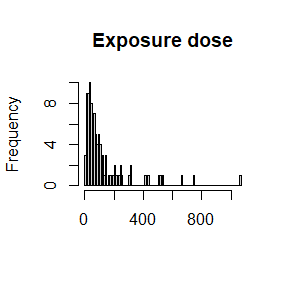

### `organ`: a simulated dataset assuming the workers at interventional radiology departments

Unlike `nuclear`, `organ` assumes that people have been exposed to radiation over several times. There are 20 people in this data, 14 of whom are male and 6 are female. Also, this data includes job information of people (`occup`).

people in organ dataset

| ID | sex | birth | occup | ID | sex | birth | occup |
| --- | --- | --- | --- | --- | --- | --- | --- |
| ID01 | male | 1985 | 1 | ID11 | male | 1965 | 6 |
| ID02 | male | 1960 | 1 | ID12 | male | 1976 | 1 |
| ID03 | male | 1979 | 6 | ID13 | female | 1986 | 5 |
| ID04 | male | 1982 | 1 | ID14 | male | 1983 | 1 |
| ID05 | male | 1981 | 6 | ID15 | male | 1980 | 1 |
| ID06 | male | 1966 | 6 | ID16 | female | 1980 | 6 |
| ID07 | female | 1980 | 1 | ID17 | male | 1982 | 6 |
| ID08 | female | 1980 | 1 | ID18 | female | 1968 | 5 |
| ID09 | male | 1992 | 1 | ID19 | male | 1965 | 1 |
| ID10 | female | 1984 | 4 | ID20 | male | 1983 | 5 |

```r
str(organ)
```

```
#> 'data.frame':    971 obs. of  11 variables:
#>  $ ID           : chr  "ID01" "ID01" "ID01" "ID01" ...
#>  $ sex          : chr  "male" "male" "male" "male" ...
#>  $ birth        : num  1985 1985 1985 1985 1985 ...
#>  $ exposure     : num  2011 2011 2011 2011 2013 ...
#>  $ site         : chr  "oesophagus" "kidney" "rectum" "thyroid" ...
#>  $ exposure_rate: chr  "chronic" "chronic" "chronic" "chronic" ...
#>  $ dosedist     : chr  "fixedvalue" "fixedvalue" "fixedvalue" "fixedvalue" ...
#>  $ dose1        : num  0.00195 0.00386 0.00386 0.0051 0.08936 ...
#>  $ dose2        : num  NA NA NA NA NA NA NA NA NA NA ...
#>  $ dose3        : num  NA NA NA NA NA NA NA NA NA NA ...
#>  $ occup        : chr  "1" "1" "1" "1" ...
```

All values of `exposure_rate` are `chronic` and all values of `dosedist` are `fixedvalue`. The birth-year of people has a range from 1960 to 1992, and the exposed age is from 23 to 60 years old.

`sex`, `birth`, `site`, and `occup` were randomly selected, and `exposure` was generated before 2021 (This means that this data assumed that the current year is 2021). The exposure dose (`dose1`) was generated from the Gaussian mixture distribution, which mimics data of workers at interventional radiology departments in Korea (Lee, et al., 2021).

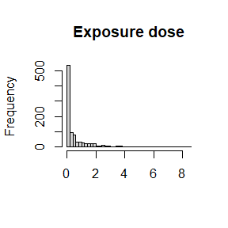

## Reference

1. De Gonzalez, A. B., et al. (2012). RadRAT: a radiation risk assessment tool for lifetime cancer risk projection. *Journal of Radiological Protection*, **32(3)**, 205.
2. Lee, W. J., Bang, Y. J., Cha, E. S., Kim, Y. M., & Cho, S. B. (2021). Lifetime cancer risks from occupational radiation exposure among workers at interventional radiology departments. *International Archives of Occupational and Environmental Health*, **94(1)**, 139-145.